# Data Structure

Ryan Farhab

2022-09-02

This is the R markdown (rmd) exercise file that accompanies the lecture notes. It will be your sandbox! Fill in the R code chunks, experiment, and have fun!

# Vector

### Vector

Use c() to construct a numeric vector, a logical vector, and a character vector:

```r
stock_price <- c(15.55, 16.23, 15.87)
logic <- c(TRUE, FALSE, FALSE, TRUE)
ticker <- c("TSLA", "F", "AAPL", "SNAP")
stock_price
```

```
## [1] 15.55 16.23 15.87
```

```r
logic
```

```
## [1]  TRUE FALSE FALSE  TRUE
```

```r
ticker
```

```
## [1] "TSLA" "F"    "AAPL" "SNAP"
```

Note that the number of members in a vector is given by the length function. Use length() to find out the length of a vector you have just calculated:

```r
length(ticker)
```

```
## [1] 4
```

*Spreadsheet*: In a spreadsheet, a vector can be represented by a row or a column of consecutive cells.

### Combining Vectors

What if you use c() to combine a vector and a single value? The single value is added to the vector!

Use c() to append a price of 100 to the vector price1:

```r
price1 <- c(10, 20, 30)

# append a price of 100 to the vector price1:

c(price1, 100)
```

```
## [1]  10  20  30 100
```

### Type Coercion

Run some code to find out how R forces the type conversion when you try to combine different data types using c():

```r
c(5.5, "TSLA")
```

```
## [1] "5.5"  "TSLA"
```

```r
c(3, TRUE)
```

```
## [1] 3 1
```

```r
c(FALSE, "World")
```

```
## [1] "FALSE" "World"
```

### Missing Data

Construct x, y, and z vectors as in the slide, and print them:

```r
(x <- c(0.5, NA, 0.7))
```

```
## [1] 0.5  NA 0.7
```

```r
(y <- c(TRUE, FALSE, NA))
```

```
## [1]  TRUE FALSE    NA
```

```r
(z <- c("a", NA, "c", "d", "e"))
```

```
## [1] "a" NA  "c" "d" "e"
```

### Find out about NA

Apply is.na to z to find out which element is NA:

```r
z <- c("a", NA, "c", "d", "e")
is.na(z)
```

```
## [1] FALSE  TRUE FALSE FALSE FALSE
```

### Plotting your vector

Plot the returns vector yourself:

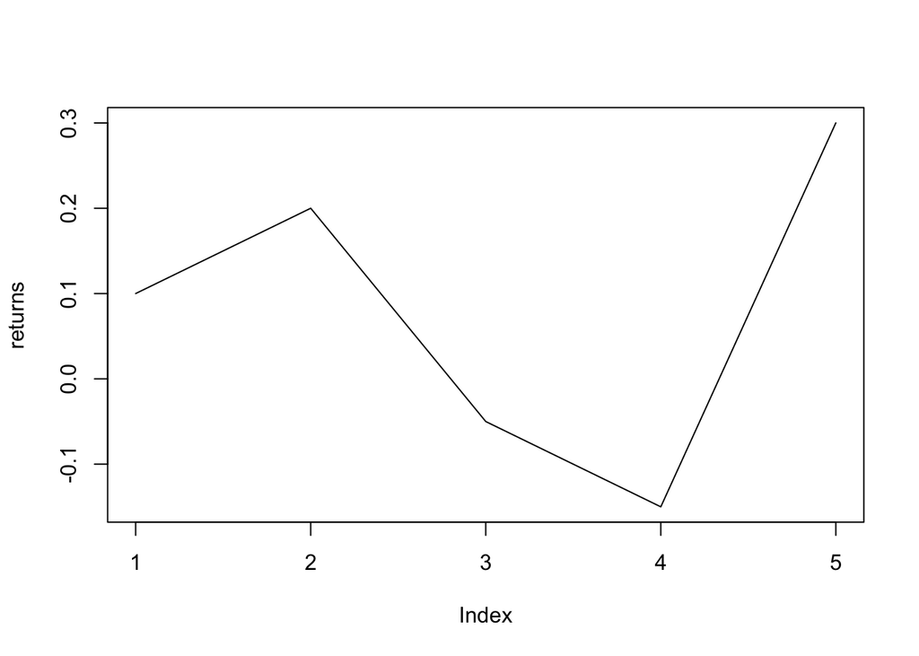

```r
returns <- c(0.1, 0.2, -0.05, -0.15, 0.3)

# plot the vector:
plot(returns, type="l")
```

Specify different values for the type parameter to generate different types of plots.

Read the documentation about the type options of plot() by issuing ?plot in the console window.

## Vector Subsetting

### Vector Index

Experiment retrieving values using index.

What if the index is out of range? In the code below, the length of the prices vector is 5. What if you try to access the 10th element by issuing prices[10]? Find out about it:

```r
prices <- c(10, 20, 30, 40, 50)
prices[10]
```

```
## [1] NA
```

### Vector Slicing: Retrieving Multiple Values

```r
prices <- c(10, 20, 30, 40, 50)

# use an index vector to retrieve multiple values from a vector:
prices[c(2,4,3)]
```

```
## [1] 20 40 30
```

### The Colon Operator

```r
prices <- c(10, 20, 30, 40, 50)

# Use the color vector to access members 3, 4, and 5 of the vector:
prices[3:5]
```

```
## [1] 30 40 50
```

More information for the colon operator is available in the R documentation. Issue the two following equivalent commands in the console:

help(“:”)

?“:”

### Logical Index Vector

```r
prices <- c(10, 20, 30, 40, 50)

# Use a logical index vector to access members 3 and 5 of the vector:

prices[c(FALSE, FALSE, TRUE, FALSE, TRUE)]
```

```
## [1] 30 50
```

### Named Vector Members

```r
prices <- c(10, 20, 30, 40, 50)
names(prices) <- c("IBM", "AAPL", "GE", "GOOG", "PG")

# Retrieve the prices of IBM and GOOG:
prices[c("IBM", "GOOG")]
```

```
##  IBM GOOG
##   10   40
```

## Vector Arithmetics

### Vector Arithmetics

Create the two vectors of a and b, and perform subtraction a-b, multiplication a*b, and division a/b:

```r
a <- c(1, 3, 5, 7)
b <- c(2, 4, 6, 8)
a-b
```

```
## [1] -1 -1 -1 -1
```

```r
a*b
```

```
## [1]  2 12 30 56
```

```r
a/b
```

```
## [1] 0.5000000 0.7500000 0.8333333 0.8750000
```

### A Portfolio of 100 Stocks

Generate a vector of 100 returns, normally distributed with mean 0.1 and standard deviation of 0.2. You will use rnorm(). Search the documentation about using this function.

```r
r <- rnorm(100, mean = 0.1, sd = 0.2)
```

Generate a vector of 100 portfolio weights, making sure that they sum up to 1. You will use runif(). Search the documentation about using this function.

```r
w_1_99 <- runif(99, min = -0.05, max = 0.05)
w_100 <- 1 - sum(w_1_99)
w <- c(w_1_99, w_100)
```

Write a loop to calculate the portfolio return:

```r
r_p <- 0

for (i in 1:100) {
  r_p <- r_p + w[i] * r[i]
}

r_p
```

```
## [1] 0.5256445
```

### Can we improve the code?

Calculate the portfolio return using vector multiplication:

```r
r_p <- sum(w * r)
r_p
```

```
## [1] 0.5256445
```

*Spreadsheet*: The spreadsheet function SUMPRODUCT can be used to calculate the portfolio return in one step!

# Matrix

### Matrix

Use the matrix() function to construct a matrix of 3 rows and two columns, with any values (must be of the same type) of your choice for the elements:

```r
A = matrix(
  c(1,2,3,4,5,6),
  nrow = 3,
  ncol = 2,
  byrow = TRUE)
A
```

```
##      [,1] [,2]
## [1,]    1    2
## [2,]    3    4
## [3,]    5    6
```

Search the documentation on matrix(), and experiment with the byrow = FALSE arguments.

*Spreadsheet*: In a spreadsheet, a matrix is represented by a two-dimensional table.

### From Vectors to Matrix

cbind() combines vectors as columns of a matrix. In the code chunk below, try rbind(), which combines vectors as rows of a matrix:

```r
# Vectors of stock prices:
AAPL <- c(105.13, 101.77, 106.41, 101.22, 103.59)
IBM <- c(153.55, 142.79, 142.75, 153.69, 152.84)
GOOG <- c(1232.02, 1096.62, 1172.75, 1280.53, 1015.38)

# Bind the vectors as rows of a matrix

prices_mat <- rbind(AAPL, IBM, GOOG)
prices_mat
```

```
##         [,1]    [,2]    [,3]    [,4]    [,5]
## AAPL  105.13  101.77  106.41  101.22  103.59
## IBM   153.55  142.79  142.75  153.69  152.84
## GOOG 1232.02 1096.62 1172.75 1280.53 1015.38
```

### Correlation

Apply cor() to the matrix of the 3 stocks prices:

```r
cor(prices_mat)
```

```
##           [,1]      [,2]      [,3]      [,4]      [,5]
## [1,] 1.0000000 0.9999988 0.9999680 0.9999991 0.9999497
## [2,] 0.9999988 1.0000000 0.9999793 0.9999957 0.9999328
## [3,] 0.9999680 0.9999793 1.0000000 0.9999561 0.9998376
## [4,] 0.9999991 0.9999957 0.9999561 1.0000000 0.9999626
## [5,] 0.9999497 0.9999328 0.9998376 0.9999626 1.0000000
```

*Spreadsheet*: Google to find out how to calculate correlation and correlation matrix in a spreadsheet.

### Matrix Subsetting

The matrix A has been constructed in the code chunk below. Experiment with the different ways to return elments of a matrix:

```r
A = matrix(
     c(1, 2, 3, 4, 5, 6), # the data elements, must be of the same type!
     nrow=2,              # number of rows
     ncol=3,              # number of columns
     byrow = TRUE)        # fill matrix by rows

# Different ways to subset A:

A[2,3]
```

```
## [1] 6
```

```r
A[2, ]
```

```
## [1] 4 5 6
```

```r
A[ ,3]
```

```
## [1] 3 6
```

```r
A[ ,c(1,3)]
```

```
##      [,1] [,2]
## [1,]    1    3
## [2,]    4    6
```

# Data Frame

### Bond Yields

The bond yields were obtained from:

https://www.gmsgroup.com/municipal-bond-market-yields

### Data Frame

Create the same data frame as in the slide:

```r
type = c("Municipals", "Municipals", "Municipals", "Corporate", "Corporate")
rating = c("AAA", "AA", "A", "AAA", "AA")
maturity = c(1, 1, 1, 3, 3)
yield = c(0.317, 0.355, 0.462, 1.1, 0.893)

corporate_muni <- data.frame(type, rating, maturity, yield)
```

### Useful Data Frame Functions

Try the head(), tail(), dim(), nrow(), ncol(), names() on the data frame you have just created above:

```r
head(corporate_muni)
```

```
##         type rating maturity yield
## 1 Municipals    AAA        1 0.317
## 2 Municipals     AA        1 0.355
## 3 Municipals      A        1 0.462
## 4  Corporate    AAA        3 1.100
## 5  Corporate     AA        3 0.893
```

```r
tail(corporate_muni)
```

```
##         type rating maturity yield
## 1 Municipals    AAA        1 0.317
## 2 Municipals     AA        1 0.355
## 3 Municipals      A        1 0.462
## 4  Corporate    AAA        3 1.100
## 5  Corporate     AA        3 0.893
```

```r
dim(corporate_muni)
```

```
## [1] 5 4
```

```r
nrow(corporate_muni)
```

```
## [1] 5
```

```r
ncol(corporate_muni)
```

```
## [1] 4
```

```r
names(corporate_muni)
```

```
## [1] "type"     "rating"   "maturity" "yield"
```

See examples at:

https://www.r-bloggers.com/exploratory-data-analysis-useful-r-functions-for-exploring-a-data-frame/

### str()

Apply str() to the data frame corporate_muni, and interpret the output:

```r
str(corporate_muni)
```

```
## 'data.frame':    5 obs. of  4 variables:
##  $ type    : chr  "Municipals" "Municipals" "Municipals" "Corporate" ...
##  $ rating  : chr  "AAA" "AA" "A" "AAA" ...
##  $ maturity: num  1 1 1 3 3
##  $ yield   : num  0.317 0.355 0.462 1.1 0.893
```

### summary()

Apply summary() to the data frame corporate_muni, and interpret the output:

```r
summary(corporate_muni)
```

```
##      type              rating             maturity       yield
##  Length:5           Length:5           Min.   :1.0   Min.   :0.3170
##  Class :character   Class :character   1st Qu.:1.0   1st Qu.:0.3550
##  Mode  :character   Mode  :character   Median :1.0   Median :0.4620
##                                        Mean   :1.8   Mean   :0.6254
##                                        3rd Qu.:3.0   3rd Qu.:0.8930
##                                        Max.   :3.0   Max.   :1.1000
```

## Accessing and subsetting data frames

### Accessing and subsetting data frames

Try the different ways to subset the data frame corporate_muni:

```r
corporate_muni[2, 3]
```

```
## [1] 1
```

```r
corporate_muni[2, ]
```

```
##         type rating maturity yield
## 2 Municipals     AA        1 0.355
```

```r
corporate_muni[ ,3]
```

```
## [1] 1 1 1 3 3
```

```r
corporate_muni[ ,c(1,3)]
```

```
##         type maturity
## 1 Municipals        1
## 2 Municipals        1
## 3 Municipals        1
## 4  Corporate        3
## 5  Corporate        3
```

You may also try the colon operator!

### Using Column Names

```r
corporate_muni[ , "yield"]
```

```
## [1] 0.317 0.355 0.462 1.100 0.893
```

```r
corporate_muni$yield
```

```
## [1] 0.317 0.355 0.462 1.100 0.893
```

### Filtering

Try the following filter exercises:

```r
# return rows of corporate bonds only:

subset(corporate_muni, type == "Corporate")
```

```
##        type rating maturity yield
## 4 Corporate    AAA        3 1.100
## 5 Corporate     AA        3 0.893
```

```r
# return rows with yields lower than 0.5%:

subset(corporate_muni, yield < 0.5)
```

```
##         type rating maturity yield
## 1 Municipals    AAA        1 0.317
## 2 Municipals     AA        1 0.355
## 3 Municipals      A        1 0.462
```

Note: we use double equal signs == for testing equality.

### Adding new columns

Think of a transformation of the yield column, and create a new column:

```r
corporate_muni$new_yield <- corporate_muni$yield + 0.2

corporate_muni
```

```
##         type rating maturity yield new_yield
## 1 Municipals    AAA        1 0.317     0.517
## 2 Municipals     AA        1 0.355     0.555
## 3 Municipals      A        1 0.462     0.662
## 4  Corporate    AAA        3 1.100     1.300
## 5  Corporate     AA        3 0.893     1.093
```

### Removing a column

Remove the new column you have just created:

```r
corporate_muni$new_yield <- NULL
corporate_muni
```

```
##         type rating maturity yield
## 1 Municipals    AAA        1 0.317
## 2 Municipals     AA        1 0.355
## 3 Municipals      A        1 0.462
## 4  Corporate    AAA        3 1.100
## 5  Corporate     AA        3 0.893
```

# Factor

### Factors

Source:

https://www.tutorialspoint.com/r/r_factors.htm

### Factor: Example

Creat a character vector of ratings and then change it to a factor:

```r
ratings <- c("BBB", "C", "AAA", "AA", "A", "AAA", "C", "BB")
factor_ratings <- factor(ratings)
factor_ratings
```

```
## [1] BBB C   AAA AA  A   AAA C   BB
## Levels: A AA AAA BB BBB C
```

Convert the factor to numeric using as.numeric(). What did you find?

```r
as.numeric(factor_ratings)
```

```
## [1] 5 6 3 2 1 3 6 4
```

### Factors in Data Frame

Use str() to check what factor columns the data frame corporate_muni consists of:

```r
# Variables
type = c("Municipals ", "Municipals ", "Municipals ",
         "Corporate ", "Corporate ")
rating = c("AAA", "AA", "A", "AAA",  "AA")
maturity = c(1, 1, 1, 3, 3)
yield = c(0.317, 0.355, 0.462,  1.1, 0.893)

# Combine the variables into a data frame
corporate_muni <- data.frame(type, rating, maturity, yield)

# apply str():
str(corporate_muni)
```

```
## 'data.frame':    5 obs. of  4 variables:
##  $ type    : chr  "Municipals " "Municipals " "Municipals " "Corporate " ...
##  $ rating  : chr  "AAA" "AA" "A" "AAA" ...
##  $ maturity: num  1 1 1 3 3
##  $ yield   : num  0.317 0.355 0.462 1.1 0.893
```

### Plotting a factor

Plot the factor you have created.

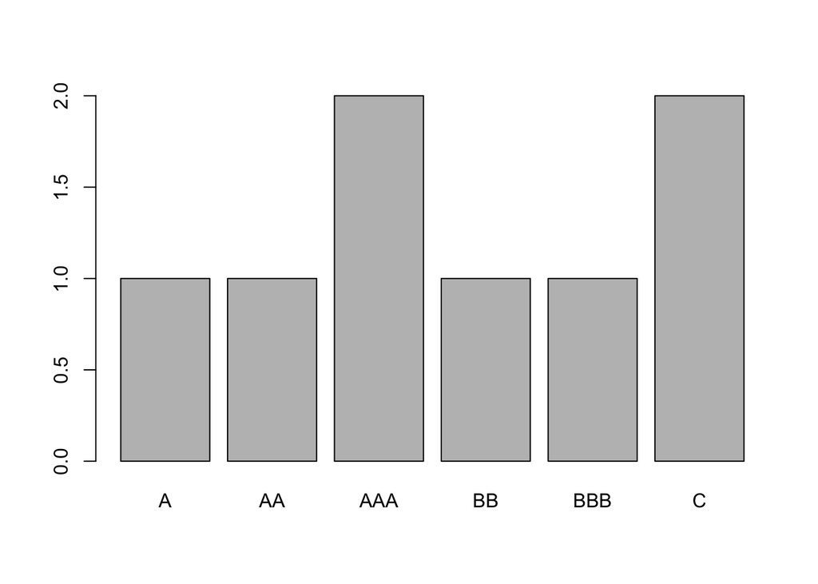

```r
plot(factor_ratings)
```

Is it valid to plot the character vector “ratings”? Experiment to find out:

```r
#plot(ratings)
#No, it is not valid to plot the vector "ratings" as it is not possible to plot a series of non-numeric character variables.
```

### Changing the Order of Levels

# List

### Lists

Readings:

https://www.tutorialspoint.com/r/r_lists.htm

### Creating a List

Create a list with mixed data types of your choice:

### Naming List Elements

Give names to the elements of the list you have created:

```r
mylist <- list(months = c("Jan", "Feb", "Mar"),
               a_matrix = matrix(c(3, 9, 5, 1, -2, 8), nrow = 2))

mylist
```

```
## $months
## [1] "Jan" "Feb" "Mar"
##
## $a_matrix
##      [,1] [,2] [,3]
## [1,]    3    5   -2
## [2,]    9    1    8
```

### Accessing List Elements

Experiment with the different ways to access the elements of your list.

```r
mylist[1]
```

```
## $months
## [1] "Jan" "Feb" "Mar"
```

```r
mylist[[1]]
```

```
## [1] "Jan" "Feb" "Mar"
```

```r
mylist$months
```

```
## [1] "Jan" "Feb" "Mar"
```

Notice the difference between [], [[]], and $? Can you Google to find out?

### Manipulating List Elements

Experiment with adding, removing, and updating your list:

```r
mylist[3] <- "New element"
mylist[3] <- NULL
mylist[2] <- "updated element"
mylist
```

```
## $months
## [1] "Jan" "Feb" "Mar"
##
## $a_matrix
## [1] "updated element"
```